# Geog533 Final Exam

Alyssa James

**What to submit:**

An **R notebook/html document** that contains the script/output for each question. Use the provided **Geog533_finalExam_template.Rmd** to complete your answers and generate the html document. Filename convention for submissions: lastname_firstname_final.zip. All data needed to complete this exam can be found in the **data.zip**. You have 120 minutes (12:50-2:50 pm) to complete the exam. There will be a 10% penalty per 10 minutes for late submissions. Each question is worth 20 points, with a total of 200 points.

## Question 1 (20 pt.)

The **iris** data set in the **datasets** package contains 150 cases (rows) and 5 variables (columns).

### Question 1(a)

Calculate the mean and variance of **Sepal.Length**.

```r
library(datasets)
df <- iris
mean <- mean(df$Sepal.Length)
mean
```

```
[1] 5.843333
```

```r
varience <- var(df$Sepal.Length)
varience
```

```
[1] 0.6856935
```

### Question 1(b)

Calculate the covariance and correlation of **Sepal.Length** and **Petal.Length**.

```r
x <- df$Sepal.Length
y <- df$Petal.Length
covSP <- cov(x, y)
covSP
```

```
[1] 1.274315
```

```r
cor <- cor.test(x, y)
cor
```

```
    Pearson's product-moment correlation

data:  x and y
t = 21.646, df = 148, p-value < 2.2e-16
alternative hypothesis: true correlation is not equal to 0
95 percent confidence interval:
 0.8270363 0.9055080
sample estimates:
      cor
0.8717538
```

### Question 1(c)

Create a scatter plot based on **Petal.Length** and **Petal.Width**.

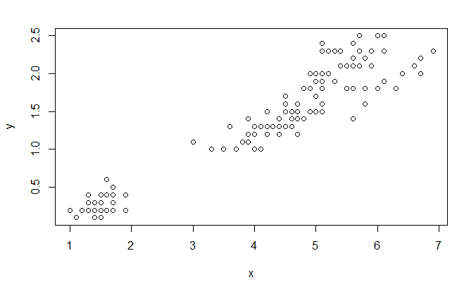

```r
x <- df$Petal.Length
y <- df$Petal.Width
plot(x, y)
```

### Question 1(d)

Create a pie chart based on **Species**.

```r
x <- df$Species
```

### Question 1(e)

There are three species (*setosa, versicolor, and virginica*). Randomly select 20 rows from each species; combine the selected rows as a new dataframe (60 rows); save the remaining 90 rows as a new dataframe.

```r
set.seed(seed = 20)
x <- sample(df$Species == "setosa")
y <- sample(df$Species == "versicolor")
z <- sample(df$Species == "virginica")
sf <- data.frame(x,y,z)
sf
```

| x | y | z |
| --- | --- | --- |
| FALSE | TRUE | TRUE |
| FALSE | TRUE | FALSE |
| TRUE | TRUE | FALSE |
| FALSE | TRUE | TRUE |
| FALSE | FALSE | TRUE |
| FALSE | FALSE | TRUE |
| TRUE | FALSE | FALSE |
| TRUE | FALSE | FALSE |
| TRUE | TRUE | TRUE |
| FALSE | FALSE | FALSE |

[output cut: 140 more lines]

## Question 2 (20 pt.)

On average, there are two bicycle thefts every ten square miles during the course of a month.

### Question 2(a)

What is the probability that there will be no bicycle thefts in a ten square mile area next month?

```r
pexp(2,rate = 1/10)
```

```
[1] 0.1812692
```

### Question 2(b)

What is the probability that there will be no bicycle thefts in a seven square mile area next month?

### Question 2(c)

What is the probability that there will be at least one bicycle theft in a 20 square mile area next month?

### Question 2(d)

What is the probability that there will be exactly one bicycle theft in a ten square mile area over the next ten days?

### Question 2(e)

What is the probability that there will be more than 20 bicycle thefts in a ten square mile area next year?

## Question 3 (20 pt.)

The mean value of annual imports for a country is normally distributed with mean $\mu=30$ million and standard deviation $\sigma=16$ million.

### Question 3(a)

What fraction of years have import values less than 20 million?

```r
library(MASS)
x <- mvrnorm(n = 20000000, mu = 30000000, Sigma = 16000000, empirical = TRUE)
t.test(x)
```

```
    One Sample t-test

data:  x
t = 33541000, df = 2e+07, p-value < 2.2e-16
alternative hypothesis: true mean is not equal to 0
95 percent confidence interval:
 3e+07 3e+07
sample estimates:
mean of x
    3e+07
```

### Question 3(b)

What fraction of years have import values more than 40 million?

```r
x <- mvrnorm(n = 20000000, mu = 30000000, Sigma = 16000000, empirical = TRUE)
t.test(x)
```

```
    One Sample t-test

data:  x
t = 33541000, df = 2e+07, p-value < 2.2e-16
alternative hypothesis: true mean is not equal to 0
95 percent confidence interval:
 3e+07 3e+07
sample estimates:
mean of x
    3e+07
```

### Question 3(c)

What dollar value of imports is exceeded only 5% of the time?

### Question 3(d)

What fraction of years have import values between 29 and 45 million?

### Question 3(e)

Plot the density function and create the shaded area between 29 and 45 million.